# A quick introduction to rarefaction analisys using Rarefy

Giovanni Bacaro, Elisa Thouverai, Enrico Tordoni, Alessandro Chiarucci, Carlo Ricotta, Duccio Rocchini, Sandrine Pavoine

2023-11-01

```r
#Required packages
require(Rarefy)
require(ade4)
require(adiv)
require(ape)
require(vegan)
```

## Introduction

**Rarefy** is an R package including a set of new functions able to cope with any diversity metric and to calculate expected values of a given taxonomic, functional or phylogenetic index for a reduced sampling size under a spatially-constrained and distance-based ordering of the sampling units. **Rarefy** and the functions therein represent an ultimate solution for ecologists to rarefy any diversity metric by taking into account the contribution of any distance-based ordination of sampling units, providing more ecological meaningful (unbiased) estimates of the expected diversities.

This vignette aims at describing some applications of the Rarefy package helping the user to calculate different types of spatially and non-spatially explicit rarefaction curves. The vignette is organized in the following sections, exploring different package features and applications:

1. Diversity indices and dataset available in Rarefy;
2. Spatially-explicit rarefaction;
3. Rarefaction of alpha diversity indices;
4. Rarefaction of beta diversity;
5. Phylogenetic spatially-explicit rarefaction;
6. Null models in rarefaction practice.

## 1. Diversity indices and dataset available in Rarefy

**Rarefy** offers the possibility to calculate a large set of diversity indices and new metrics will be implemented in future packages updates. In the table below, for functions implemented in **Rarefy**, the set of indices available are detailed.

[output not shown]

## 2. Spatially-explicit rarefaction

Here we provided a classic example for the calculation of the taxonomic spatially-explicit rarefaction curve using the `duneFVG` data included in **Rarefy**, as described for the first time by Chiarucci et al. (2009).

The datasets are loaded as follows:

```r
data("duneFVG") #plot/species matrix
data("duneFVG.xy") #plots geographic coordinates
```

Firstly, a pairwise euclidean distance matrix between sampling units is calculated using the sampling unit coordinates:

```r
dist_sp<-dist(duneFVG.xy$tot.xy)
```

Then, using the `directionalSAC` function, the spatially-explicit rarefaction curve can be directly compared with the classic rarefaction:

```r
ser_rarefaction<-directionalSAC(duneFVG$total,dist_sp)
```

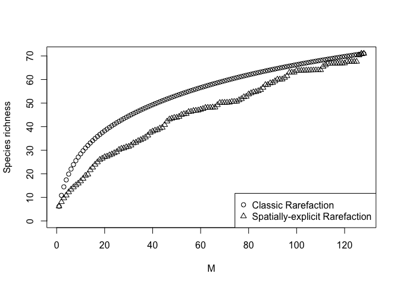

```r
plot(1:128,ser_rarefaction$N_Exact,xlab="M",ylab="Species richness",ylim=c(0,71),pch=1)
points(1:128,ser_rarefaction$N_SCR,pch=2)
legend("bottomright",legend=c("Classic Rarefaction","Spatially-explicit Rarefaction"),pch=1:2)
```

## 4. Rarefaction of beta diversity

Spatially-explicit or gradient-oriented (directional) turnover curves as a function of sampling effort have been firstly defined by Ricotta et al. (2019). The methodology to construct the directional curve relies on the standard procedure in which adjacent plots are combined step by step using the specified distance among plots as a constraining factor. In the simplest case, given a set of *N* plots, for each plot, the first, second, …, *k-th* nearest neighbor are determined and a directional beta diversity curve is constructed using the resulting sequence of plots. This procedure is repeated for all plots, generating *N* directional curves from which a mean spatially explicit beta diversity curve is calculated. The resulting curve is thus an intermediate solution between a non-directional beta diversity curve and a pure directional curve in which all plots are ordered along a single spatial or environmental gradient. `directionalSAC` can be used to calculate directional, normalized directional, non-directional, normalized non-directional beta diversity as a function of sampling effort. A normalized measure of autocorrelation for directional beta diversity calculated as the normalized difference between directional and non-directional beta is also available.

An example of the directional rarefaction of beta diversity is here provided using the `mite` dataset available in the `vegan` package (Oksanen et al. 2020). The same example is discussed in Appendix 1 in Ricotta et al. (2019).

```r
data(mite)
data(mite.env)
comm_matrix<-mite
```

To calculate and compare directional and non directional beta diversity along the environmental gradient defined according to the substrate density (g/L), the `directionalSAC` function can be used as follows:

```r
beta_directional<-directionalSAC(comm_matrix,mite.env$SubsDens)
```

Finally, directional and non-directional beta curves can be visually compared.

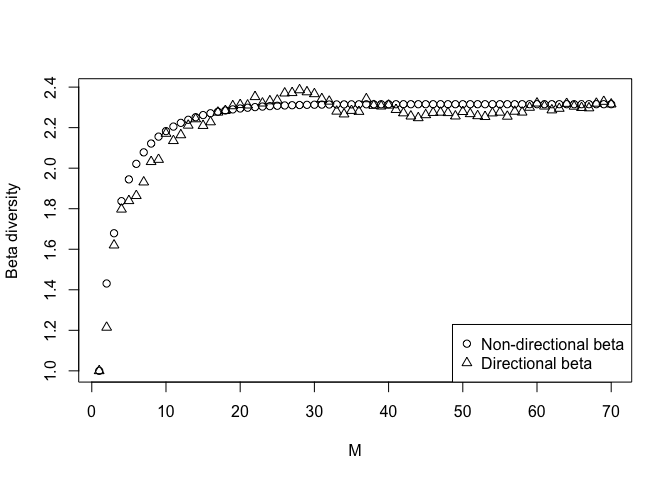

```r
plot(1:70,beta_directional$Beta_M,xlab="M",ylab="Beta diversity",ylim=range(c(beta_directional$Beta_M_dir,beta_directional$Beta_M)))
points(1:70,beta_directional$Beta_M_dir,pch=2)
legend("bottomright",legend=c("Non-directional beta","Directional beta"),pch=1:2)
```

## Spatially-explicit functional rarefaction curve

This curve represents an extension of the standard non-directional functional rarefaction for species abundance data proposed in Ricotta et al. (2012), where the spatial component (Euclidean distance among plots) is used to calculate the expected value of the functional diversity (expressed through Rao’s Q) as a function of the cumulated number of plots, taking into account the similarity in species composition due to the sampling unit proximity.

In the following example, community, site location and functional traits available in the `duneFVG` dataset are used:

```r
data(duneFVG)
data(duneFVG.xy)
data(duneFVG.tr8)
```

Firstly, a functional distance matrix is calculated among species using species functional traits. Considering the different nature of these variable (ordinal, qualitative and continuous) the modified Gower distance measure (Pavoine et al., 2009) is calculated using the function `disk.ktab` available in the `ade4` package. A matrix of pairwise distances between species using the available functional traits was thus calculated:

```r
tr8_N<-duneFVG.tr8$traits.tot[,c(1,3,4)]
tr8_D<-data.frame(duneFVG.tr8$traits.tot[,2])
tr8_Q<-duneFVG.tr8$traits.tot[,5:15]
tr8dist<-dist.ktab(ktab.list.df(list(tr8_N,tr8_D,tr8_Q)),type=c('N','D','Q'))
```

A plot-to-plot Euclidean distance matrix is then calculated with the `dist` function and using the plot coordinates as input:

```r
dist_sp<-dist(duneFVG.xy$tot.xy,method="euclidean")
```

Finally, the spatially-explicit functional rarefaction using the Rao’s Q index can be derived:

```r
rare_Q<-ser_functional(duneFVG$total,tr8dist,dist_sp,method='rao',comparison=TRUE)
```

By setting the argument comparison=TRUE, a classic functional rarefaction curve is also calculated and its values are provided in the output for direct comparison with the spatial-explicit counterpart.

A plot can be displayed to visually compare the calculated spatially-explicit vs. classic functional rarefaction curves :

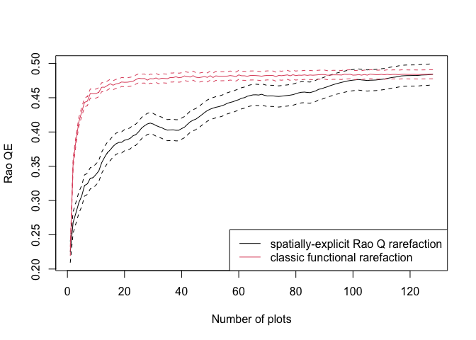

```r
plot(rare_Q [,1],ylab="Rao QE",xlab="Number of plots",type="l",ylim=range(rare_Q, na.rm=TRUE))
lines(rare_Q[,2],lty=2)
lines(rare_Q[,3],lty=2)
lines(rare_Q[,4 ],col=2)
lines(rare_Q[,5],lty=2, col=2)
lines(rare_Q[,6],lty=2, col=2)
legend("bottomright",legend=c("spatially-explicit Rao Q rarefaction","classic functional rarefaction"),lty=1,col=1:2)
```

## 6. Null models in rarefaction practice

When communities are characterized by large difference in terms of species richness, it may be necessary to standardize rarefaction curves by accounting for this aspect. Null model based on re-sampling of the community can help to overcome the task. In the following example, discussed in Tordoni et al. (2019), we would like to compare functional rarefaction curves between native and alien species (62 and 9, respectively) sampled in the `duneFVG` study. In order to exclude that the expected lower functional diversity in alien species was merely driven by the imbalance in species number between alien and natives species, we built the `rao_permuted` function to test the expected functional rarefaction curve by means of species re-sampling and null model simulations. In brief, the function works in three stages: 1) from the total set of *S* species (62 native species in the example) sampled in *M* sampling units (128 plots in `duneFVG`), a defined number of s species (with *s<S*, 9 species in the example, corresponding to the alien species richness) is randomly selected; the *s* number of species is derived from a reference community (alien species in our example) passed to the function via the `comm_str` argument; 2) a functional dissimilarity matrix for the set of the *s* randomly selected species is calculated using their associated functional traits and then the rarefied Rao Q index is calculated for the set of *M* sampling units considering abundance of a reference plant community (the structure of the reference community passed to the function via the `comm_str` argument). 3) For each permutation, step 1 and 2 are repeated and the functional rarefaction curves are then averaged over the *N* permutations. The functional rarefaction curve thus obtained (that we can identify, in the example, as the average functional rarefaction curve of a community of 9 native species with the same structure of the reference alien community) can be compared to the functional rarefaction curve calculated for the community of reference, and the deviation from the two curves (when positive or negative) can be evaluated as an effect of environmental filtering, niche differentiation or biotic homogeneization, alternatively.

In terms of code, the example can be run as follows: first data for alien and native species should be loaded and a functional pairwise distance matrix between native species using the Gower dissimilarity proposed by Pavoine et al. (2009)

```r
data(duneFVG.tr8) #species functional traits
tr8_N<-duneFVG.tr8$traits.nat[,c(1,3,4)]
tr8_D<-data.frame(duneFVG.tr8$traits.nat[,2])
tr8_Q<-duneFVG.tr8$traits.nat[,5:15]
tr8dist<-dist.ktab(ktab.list.df(list(tr8_N,tr8_D,tr8_Q)),type=c('N','D','Q'))
```

The standardized functional rarefaction curve is then calculated using the pairwise functional distance of native species and the alien assemblage as reference community.

```r
rareperm<-rao_permuted(duneFVG$alien,tr8dist)
```

The functional rarefaction curves for the native and alien species are then calculated to be compared with the standardized functional rarefaction

```r
tr8n_N<-duneFVG.tr8$traits.nat[,c(1,3,4)]
tr8n_D<-data.frame(duneFVG.tr8$traits.nat[,2])
tr8n_Q<-duneFVG.tr8$traits.nat[,5:15]
tr8a_N<-duneFVG.tr8$traits.ali[,c(1,3,4)]
tr8a_D<-data.frame(duneFVG.tr8$traits.ali[,2])
tr8a_Q<-duneFVG.tr8$traits.ali[,5:15]
tr8ndist<-dist.ktab(ktab.list.df(list(tr8n_N,tr8n_D,tr8n_Q)),type=c('N','D','Q'))
tr8adist<-dist.ktab(ktab.list.df(list(tr8a_N,tr8a_D,tr8a_Q)),type=c('N','D','Q'))
raren<-rare_Rao(duneFVG$native,tr8ndist)
rarea<-rare_Rao(duneFVG$alien,tr8adist)
```

And visually assessed to determine the degree of divergence

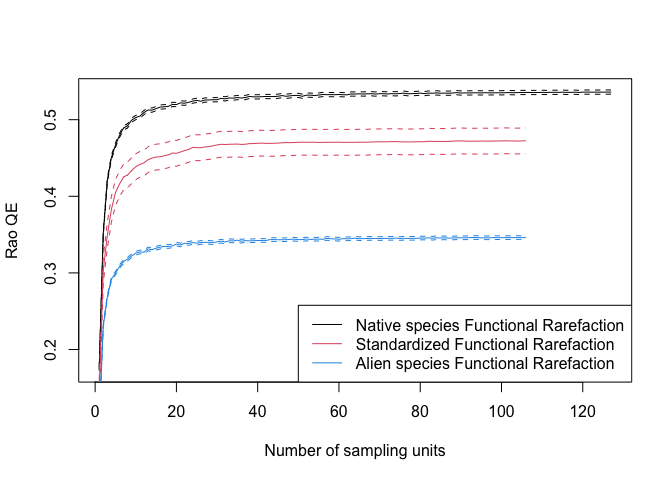

```r
plot(raren[,1], ylab="Rao QE",xlab="Number of sampling units",type="l",ylim=range(raren))
lines(raren[,2],lty=2)
lines(raren[,3],lty=2)
lines(rareperm[,1],col=2)
lines(rareperm[,2],lty=2,col=2)
lines(rareperm[,3],lty=2,col=2)
lines(rarea[,1],col=4)
lines(rarea[,2],lty=2,col=4)
lines(rarea[,3],lty=2,col=4)
legend("bottomright", legend=c("Native species Functional Rarefaction","Standardized Functional Rarefaction","Alien species Functional Rarefaction"),lty=1,col=c(1,2,4))
```

## Cited Literature

Barker, G.M. (2002) Phylogenetic diversity: a quantitative framework for measurement of priority and achievement in biodiversity conservation. Biological Journal of the Linnean Society 76, 165-194.

Bray, J.R. & Curtis, J.T. (1957) An Ordination of the Upland Forest Communities of Southern Wisconsin. Ecological Monographs 27, 325-349.

Chao, A., Chiu, C.‐H., Villéger, S., Sun, I‐F., Thorn, S., Lin, Y.‐C., Chiang, J.‐M., Sherwin, W.B. (2019) An attribute‐diversity approach to functional diversity, functional beta diversity, and related (dis)similarity measures. Ecological Monographs 89(2), e01343.

Chiarucci, A., Bacaro, G., Rocchini, D., Ricotta, C., Palmer, M., & Scheiner S. (2009) Spatially constrained rarefaction: Incorporating the autocorrelated structure of biological communities into sample-based rarefaction. Community Ecology 10(2), 209-214.

Cody, M.L. (1975) Towards a theory of continental species diversities: bird distributions over Mediterranean habitat gradients. In: Cody M.L. & Diamond J.M. (eds) Ecology and Evolution of Communities (pp. 214–257). Harvard: Belknap Press.

Daròczy, Z. (1970) Generalized information functions. Inform. Control 16, 36-51.

Daru, B.H., Karunarathne, P. & Schliep, K. (2020) phyloregion: R package for biogeographic regionalization and macroecology. Methods Ecol Evol, 11, 1483-1491. .

Faith, DP. (1992) Conservation evaluation and phylogenetic diversity. Biol. Conserv. 61, 1–10.

Havrda, J., & Charvát, F. (1967) Quantification Method of Classification Processes. Concept of Structural-Entropy. Kybernetika 3, 30-35.

Hill, M.O. (1973) Diversity and Evenness: A Unifying Notation and Its Consequences. Ecology 54, 427-432.

Jaccard, P. (1912), The Distribution of the flora in the alpine zone. New Phytologist 11(2): 37–50.

Jaccard, P. (1901), Étude comparative de la distribution florale dans une portion des Alpes et des Jura. Bulletin de la Société vaudoise des sciences naturelles 37, 547–579.

Oksanen, J., Guillaume Blanchet, F., Friendly, M., Kindt, R., Legendre, P., McGlinn, D., … Wagner H. (2020) vegan: Community Ecology Package. R package version 2.5-3.

Pavoine, S., Vallet, J., Dufour, A. B., Gachet, S., & Daniel, H. (2009) On the challenge of treating various types of variables: application for improving the measurement of functional diversity. Oikos, 118(3), 391-402.

Pavoine, S., & Ricotta, C. (2019) A simple translation from indices of species diversity to indices of phylogenetic diversity. Ecological Indicators 101, 552-561.

Pavoine, S. (2020) adiv: an R package to analyse biodiversity in ecology. Methods Ecol Evol, 11, 1106-1112.

Rao C.R. (1982) Diversity and dissimilarity coefficients: a unified approach. Theoretical Population Biology 21, 24-43.

Ricotta, C., Acosta, T.R.A., Bacaro, G., Carboni, M., Chiarucci, A., Rocchini, D., Pavoine, S. (2019) Rarefaction of beta diversity. Ecolological Indicators, 107, 105606.

Tordoni, E., Petruzzellis, F., Nardini, A., Savi, T., & Bacaro, G. (2019) Make it simpler: Alien species decrease functional diversity of coastal plant communities. J Veg Sci, 30, 498– 509.

Tsallis, C. (1988) Possible generalization of Boltzamnn-Gibbs Statistics. J. Stat. Phys. 52, 479-487.

Whittaker, R.H. (1972) Evolution and measurement of species diversity. Taxon 21, 213– 251.

Whittaker, R.H. (1960) Vegetation of the Siskiyou mountains, Oregon and California. Ecological Monographs 30, 279–338.